# Réduction de dimensionnalité et Clustering

```r
library(ggplot2)
library(gridExtra)
library(dplyr)
library(plotly)
library(scatterplot3d)
library(ggpubr)
library(FactoMineR)
library(factoextra)
library(corrplot)
library(xtable)
library(Factoshiny)
library(viridis)
library(NbClust)
library(cluster)
library(dbscan)
library(reshape2)
library(tidyverse)
```

```r
# Thème personnel
blue_theme <- function() {
  theme(
    # add border
    panel.border = element_rect(colour = "blue", fill = NA, linetype = 2),
    # color background
    panel.background = element_rect(fill = "aliceblue"),
    # modify grid
    panel.grid.major.x = element_line(colour = "steelblue", linetype = 3, linewidth = 0.5),
    panel.grid.minor.x = element_blank(),
    panel.grid.major.y =  element_line(colour = "steelblue", linetype = 3, linewidth = 0.5),
    panel.grid.minor.y = element_blank(),
    # modify text, axis and colour
    axis.text = element_text(colour = "steelblue", face = "italic"),
    axis.title = element_text(colour = "steelblue"),
    axis.ticks = element_line(colour = "steelblue"),
    # text elements
    plot.title = element_text(size = 16, face = 'bold', hjust = 0, vjust = 2, color="steelblue"),
    plot.subtitle = element_text(size = 12),
    plot.caption = element_text(size = 9, hjust = 1),
    # legend at the bottom
    legend.position = "bottom"
  )
}
```

# Réduction de dimensionnalité

## Projet 1

```r
data_I = iris
str(data_I)
```

```
'data.frame':   150 obs. of  5 variables:
 $ Sepal.Length: num  5.1 4.9 4.7 4.6 5 5.4 4.6 5 4.4 4.9 ...
 $ Sepal.Width : num  3.5 3 3.2 3.1 3.6 3.9 3.4 3.4 2.9 3.1 ...
 $ Petal.Length: num  1.4 1.4 1.3 1.5 1.4 1.7 1.4 1.5 1.4 1.5 ...
 $ Petal.Width : num  0.2 0.2 0.2 0.2 0.2 0.4 0.3 0.2 0.2 0.1 ...
 $ Species     : Factor w/ 3 levels "setosa","versicolor",..: 1 1 1 1 1 1 1 1 1 1 ...
```

```r
head(data_I)
```

|  | Sepal.Length | Sepal.Width | Petal.Length | Petal.Width | Species |
| --- | --- | --- | --- | --- | --- |
| 1 | 5.1 | 3.5 | 1.4 | 0.2 | setosa |
| 2 | 4.9 | 3.0 | 1.4 | 0.2 | setosa |
| 3 | 4.7 | 3.2 | 1.3 | 0.2 | setosa |
| 4 | 4.6 | 3.1 | 1.5 | 0.2 | setosa |
| 5 | 5.0 | 3.6 | 1.4 | 0.2 | setosa |
| 6 | 5.4 | 3.9 | 1.7 | 0.4 | setosa |

```r
# Fonction de tabulation de certaines données
variable_details <- function(data) {
    n_observations <- nrow(data)
    df <- data.frame(
        Variable = names(data),
        Type = sapply(data, class),
        Missing_Percent = sapply(data, function(x) sum(is.na(x)) / n_observations * 100)
    )

    # Calcul des statistiques uniquement pour les variables numériques
    num_vars <- data[sapply(data, is.numeric)]
    stats <- sapply(num_vars, function(x) {
        c(
            Mean = mean(x, na.rm = TRUE),
            SD = sd(x, na.rm = TRUE),
            Median = median(x, na.rm = TRUE),
            Min = min(x, na.rm = TRUE),
            Max = max(x, na.rm = TRUE)
        )
    })

    # Ajouter les statistiques au tableau principal
    stats_df <- as.data.frame(t(stats))
    df <- merge(df, stats_df, by.x = "Variable", by.y = "row.names", all.x = TRUE)

    return(df)
}


tableau1 <- variable_details(data_I)

# Renommer les colonnes de tableau 2
colnames(tableau1) <- c("Variables", "Type", "%_NA", "Moyenne", "Ecart-type", "Médiane", "Min", "Max")

print(tableau1)
```

| Variables | Type | %_NA | Moyenne | Ecart-type | Médiane | Min | Max |
| --- | --- | --- | --- | --- | --- | --- | --- |
| Petal.Length | numeric | 0 | 3.758000 | 1.7652982 | 4.35 | 1.0 | 6.9 |
| Petal.Width | numeric | 0 | 1.199333 | 0.7622377 | 1.30 | 0.1 | 2.5 |
| Sepal.Length | numeric | 0 | 5.843333 | 0.8280661 | 5.80 | 4.3 | 7.9 |
| Sepal.Width | numeric | 0 | 3.057333 | 0.4358663 | 3.00 | 2.0 | 4.4 |
| Species | factor | 0 | NA | NA | NA | NA | NA |

```r
NA
```

```r
# Recherche des doublons
doublons <- duplicated(data_I)

# Affichage des lignes qui sont des doublons
iris_doublons <- data_I[doublons, ]

# Nombre de doublons
nombre_doublons <- sum(doublons)

# Affichage du nombre de doublons
print(paste("Nombre de doublons:", nombre_doublons))
```

```
[1] "Nombre de doublons: 1"
```

```r
# Affichage des lignes doublons (si nécessaire)
print(iris_doublons)
```

|  | Sepal.Length | Sepal.Width | Petal.Length | Petal.Width | Species |
| --- | --- | --- | --- | --- | --- |
| 143 | 5.8 | 2.7 | 5.1 | 1.9 | virginica |

```r
NA
```

```r
# iris nettoyé
iris_clean <- data_I[-143, ]
```

```r
#décharge de la mémoire
rm(tableau1, latex_code, iris_doublons, doublons, nombre_doublons)
```

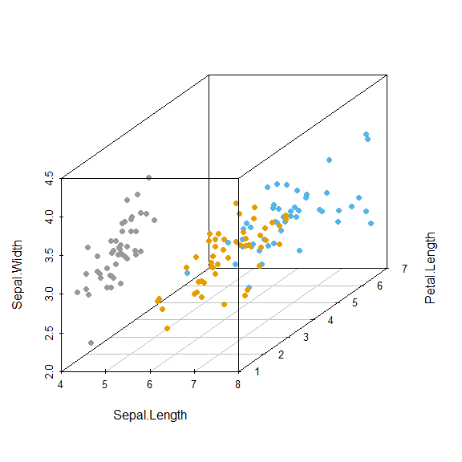

```r
# Assigner des couleurs selon l'espèce
colors <- c("#999999", "#E69F00", "#56B4E9")
colors <- colors[as.numeric(iris_clean$Species)]

# Créer le scatterplot 3d avec données non standardisées
scatterplot3d(iris_clean[, c("Sepal.Length", "Petal.Length", "Sepal.Width")],
                    pch=16,  color=colors)
```

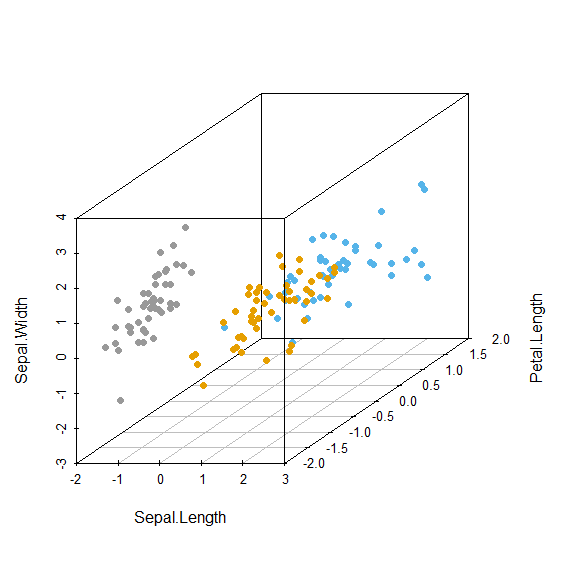

```r
# scatterplot 3d sur données centrées-réduites
iris_scaled <- scale(iris_clean[, c("Sepal.Length", "Petal.Length", "Sepal.Width")])
scatterplot3d(iris_scaled, pch = 16, color=colors)
```

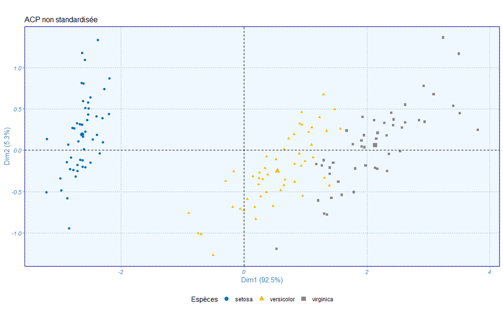

```r
# Réaliser l'ACP sur iris sans standardisation des données
res.acp1 <- PCA(iris_clean, quali.sup = "Species", scale.unit=FALSE, graph=FALSE)

# Afficher les individus sur les deux premières composantes
ACP1 <- fviz_pca_ind(res.acp1, axe = 1:2,
             geom.ind = "point",
             col.ind = iris_clean$Species,
             title = "",
             subtitle = "ACP non standardisée",
             legend.title = "Espèces",
             palette = "jco") +
  blue_theme()
ACP1
```

```r
summary.PCA(res.acp1, ncp = 2)
```

```
Call:
PCA(X = iris_clean, scale.unit = FALSE, quali.sup = "Species",
     graph = FALSE)


Eigenvalues
                       Dim.1   Dim.2   Dim.3   Dim.4
Variance               4.215   0.240   0.078   0.024
% of var.             92.497   5.277   1.703   0.523
Cumulative % of var.  92.497  97.774  99.477 100.000

Individuals (the 10 first)
                 Dist    Dim.1    ctr   cos2    Dim.2    ctr   cos2
1            |  2.693 | -2.674  1.139  0.986 |  0.319  0.284  0.014 |
2            |  2.720 | -2.705  1.165  0.988 | -0.179  0.089  0.004 |
3            |  2.883 | -2.880  1.321  0.997 | -0.145  0.058  0.003 |
4            |  2.756 | -2.736  1.192  0.986 | -0.318  0.282  0.013 |
5            |  2.741 | -2.719  1.177  0.984 |  0.327  0.299  0.014 |
6            |  2.394 | -2.270  0.821  0.899 |  0.742  1.536  0.096 |
7            |  2.825 | -2.811  1.259  0.990 | -0.088  0.021  0.001 |
8            |  2.622 | -2.616  1.090  0.996 |  0.163  0.074  0.004 |
9            |  2.935 | -2.878  1.319  0.961 | -0.578  0.933  0.039 |
10           |  2.674 | -2.663  1.129  0.992 | -0.115  0.037  0.002 |

Variables
                Dim.1    ctr   cos2    Dim.2    ctr   cos2
Sepal.Length |  0.745 13.155  0.809 |  0.320 42.492  0.149 |
Sepal.Width  | -0.172  0.704  0.157 |  0.360 53.962  0.686 |
Petal.Length |  1.758 73.335  0.996 | -0.085  3.023  0.002 |
Petal.Width  |  0.735 12.805  0.934 | -0.035  0.523  0.002 |

Supplementary categories
                  Dist     Dim.1    cos2  v.test     Dim.2    cos2  v.test
setosa       |   2.640 |  -2.633   0.995 -11.087 |   0.191   0.005   3.363 |
versicolor   |   0.609 |   0.542   0.793   2.284 |  -0.251   0.170  -4.425 |
virginica    |   2.136 |   2.133   0.997   8.847 |   0.061   0.001   1.067 |
```

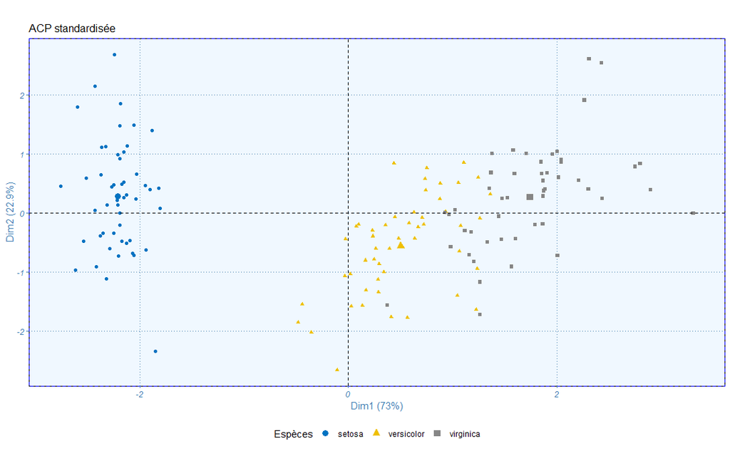

```r
# Réaliser l'ACP sur iris sans standardisation des données
res.acp1_std <- PCA(iris_clean, quali.sup = "Species", scale.unit=TRUE, graph=FALSE)

# Afficher les individus sur les deux premières composantes
ACP2 <- fviz_pca_ind(res.acp1_std, axe = 1:2,
             geom.ind = "point",
             col.ind = iris_clean$Species,
             title = "",
             subtitle = "ACP standardisée",
             legend.title = "Espèces",
             palette = "jco") +
  blue_theme()
ACP2
```

```r
summary.PCA(res.acp1_std, ncp = 2)
```

```
Call:
PCA(X = iris_clean, scale.unit = TRUE, quali.sup = "Species",
     graph = FALSE)


Eigenvalues
                       Dim.1   Dim.2   Dim.3   Dim.4
Variance               2.920   0.914   0.145   0.021
% of var.             72.991  22.858   3.631   0.520
Cumulative % of var.  72.991  95.849  99.480 100.000

Individuals (the 10 first)
                 Dist    Dim.1    ctr   cos2    Dim.2    ctr   cos2
1            |  2.307 | -2.253  1.167  0.954 |  0.479  0.169  0.043 |
2            |  2.193 | -2.071  0.986  0.892 | -0.674  0.334  0.095 |
3            |  2.378 | -2.353  1.273  0.979 | -0.340  0.085  0.020 |
4            |  2.368 | -2.289  1.204  0.934 | -0.595  0.260  0.063 |
5            |  2.464 | -2.377  1.299  0.931 |  0.647  0.307  0.069 |
6            |  2.543 | -2.062  0.978  0.658 |  1.487  1.624  0.342 |
7            |  2.456 | -2.432  1.360  0.981 |  0.050  0.002  0.000 |
8            |  2.234 | -2.221  1.134  0.988 |  0.223  0.036  0.010 |
9            |  2.582 | -2.325  1.242  0.811 | -1.112  0.908  0.186 |
10           |  2.238 | -2.174  1.086  0.943 | -0.469  0.162  0.044 |

Variables
                Dim.1    ctr   cos2    Dim.2    ctr   cos2
Sepal.Length |  0.892 27.255  0.796 |  0.357 13.938  0.127 |
Sepal.Width  | -0.457  7.166  0.209 |  0.884 85.536  0.782 |
Petal.Length |  0.992 33.676  0.983 |  0.023  0.059  0.001 |
Petal.Width  |  0.965 31.903  0.931 |  0.065  0.466  0.004 |

Supplementary categories
                  Dist     Dim.1    cos2  v.test     Dim.2    cos2  v.test
setosa       |   2.232 |  -2.213   0.983 -11.197 |   0.289   0.017   2.611 |
versicolor   |   0.755 |   0.503   0.443   2.543 |  -0.556   0.541  -5.024 |
virginica    |   1.772 |   1.745   0.970   8.699 |   0.272   0.024   2.425 |
```

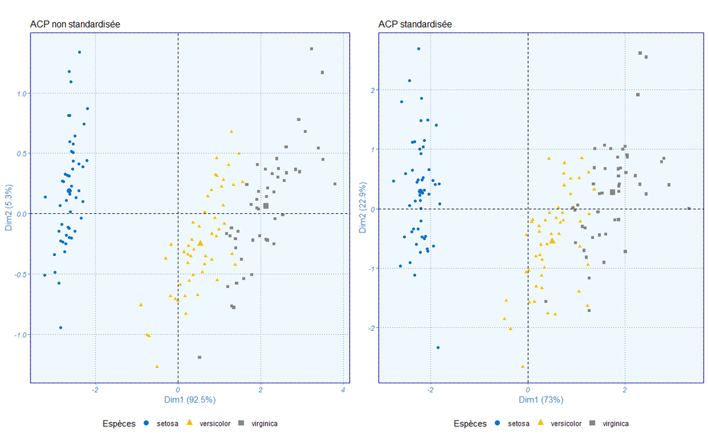

```r
grid.arrange(ACP1, ACP2, ncol = 2)
```

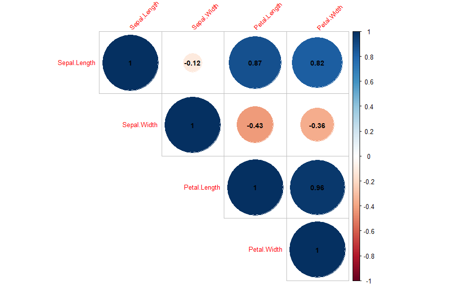

```r
# construction de la matrice des corrélations
cor_matrix <- cor(iris_clean[, -5])  # On exclut la 5ème colonne du df (colonne des espèces, variable catégorielle)

# construction du corréloghramme issu de la matrice des corrélations

corrplot(cor_matrix, method = "circle", sig.level = 0.05, insig = "blank", bg = "white",
         addCoef.col = "black", tl.srt = 45, number.cex = 0.9, type = "upper", tl.cex = 0.8)
```

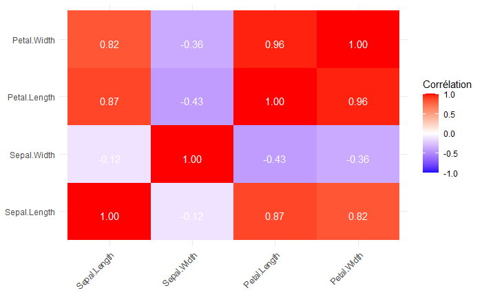

```r
## Alternative case pleine ##
# Mise en forme longue de la matrice de corrélation pour ggplot2
melted_cor_matrix <- melt(cor_matrix)

# Création du corréllogramme avec ggplot2
ggplot(melted_cor_matrix, aes(Var1, Var2, fill = value)) +
  geom_tile() + # Utilisation de tuiles pour représenter les valeurs de corrélation
  geom_text(aes(label = sprintf("%.2f", value)), vjust = 1, color = "white") +
  scale_fill_gradient2(low = "blue", high = "red", mid = "white",
                       midpoint = 0, limit = c(-1,1), space = "Lab",
                       name="Corrélation") +
  theme_minimal() +
  theme(axis.text.x = element_text(angle = 45, vjust = 1, hjust=1),
        axis.title = element_blank())
```

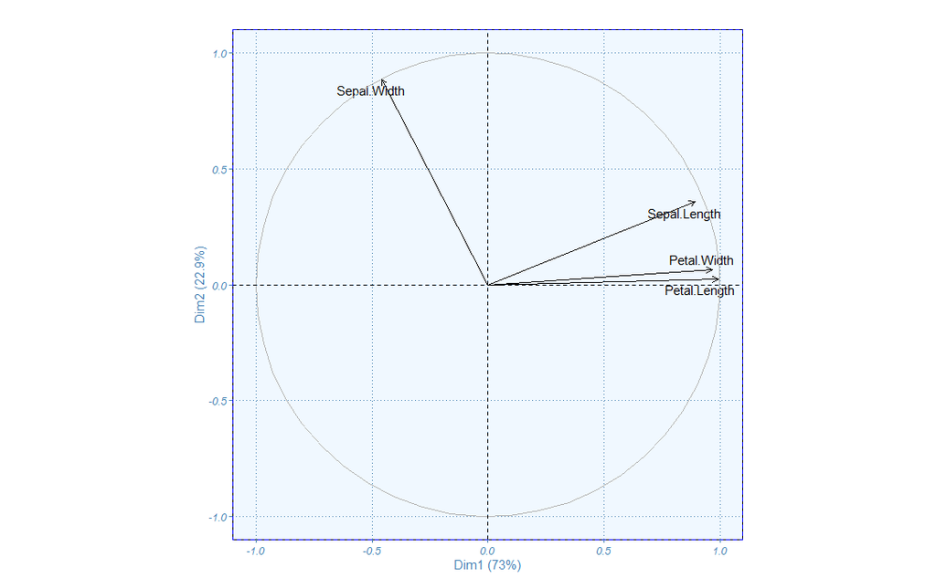

```r
fviz_pca_var(res.acp1_std, col.var = "black", repel = TRUE, title = "") +
  blue_theme()
```

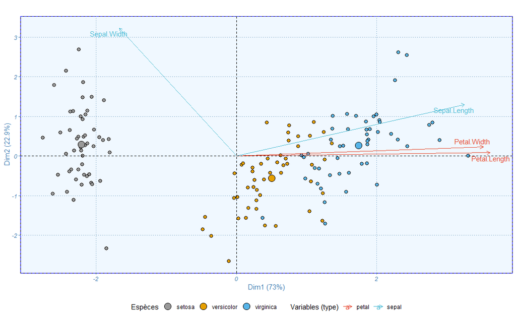

```r
biplot1 <- fviz_pca_biplot(res.acp1_std,
                # colorer (fill) les individu par groupe
                geom.ind = "point",
                pointshape = 21,
                pointsize = 2.5,
                fill.ind = iris_clean$Species,
                label = "var",
                # colorer les variables par groupe
                col.var = factor(c("sepal", "sepal", "petal", "petal")),

                legend.title = list(fill = "Espèces", color = "Variables (type)"),
                repel = TRUE,
                title = "" # Éviter le surdimensionnement des étiquettes
             ) +
  fill_palette(c("#999999", "#E69F00", "#56B4E9")) +      # remplissage des individus
  color_palette("npg") +
  blue_theme()

biplot1
```

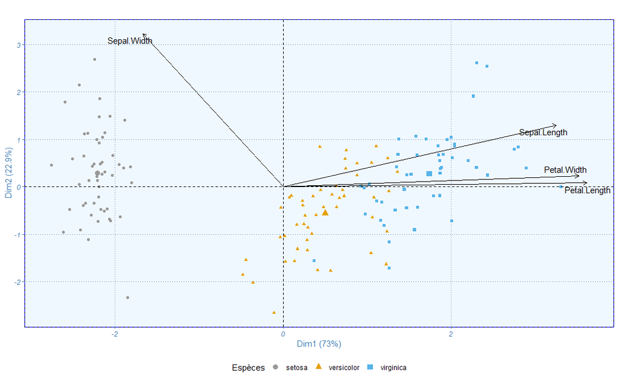

```r
fviz_pca_biplot(res.acp1_std,
                col.ind = iris_clean$Species, palette = c("#999999", "#E69F00", "#56B4E9"),
                label = "var",
                col.var = "black", repel = TRUE,
                legend.title = "Espèces",
                title = "") +
  blue_theme()
```

La part de variance représentée dans ce plan (standardisé) est de 95, 9%.

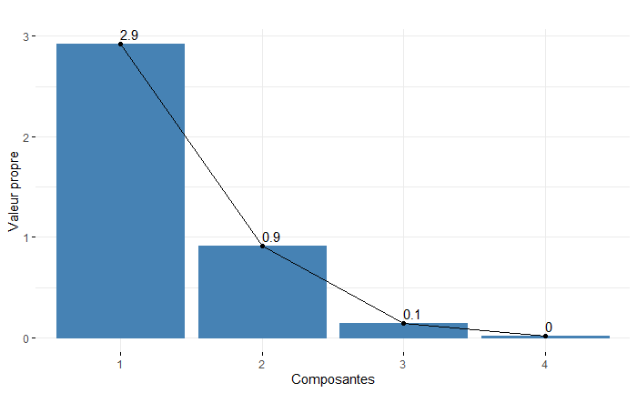

```r
#Scree plot
plot1 <- fviz_screeplot(res.acp1_std, choice ="eigenvalue", addlabels = TRUE,
                     x="Composantes",
                     y="Valeur propre",
                    title="")
plot1
```

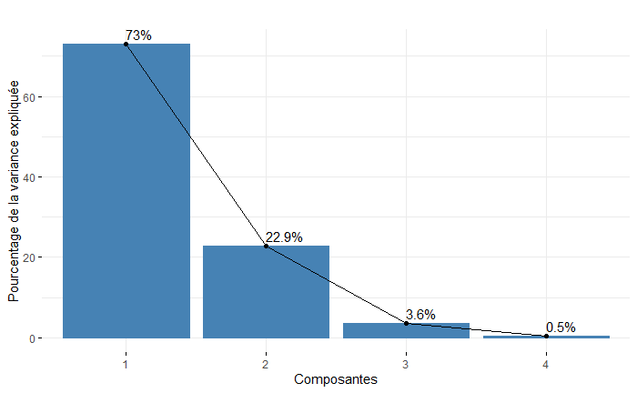

```r
plot2 <- fviz_screeplot(res.acp1_std, choice ="variance", addlabels = TRUE,
                     x="Composantes",
                     y="Pourcentage de la variance expliquée",
                     title="")
plot2
```

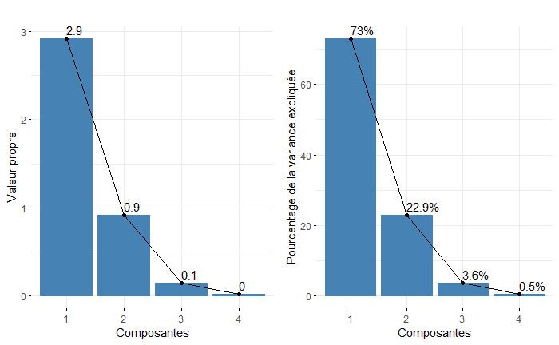

```r
ggarrange(plot1, plot2)
```

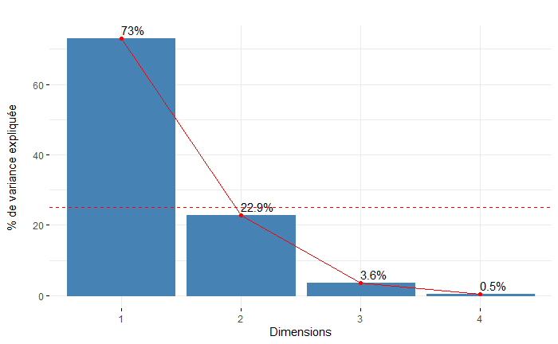

```r
#Scree plot et détermination
fviz_screeplot(res.acp1_std,
               addlabels = TRUE,
               choice ="variance",
               main = "",
               ylab = "% de variance expliquée\n",
               linecolor = "red") +
  geom_hline(yintercept = 1/ncol(iris_clean[, -5])*100, linetype = "dashed", color = "red") # visualisation de la moyenne des variances (25%)
```

```r
## Modèle de bâtons brisés ##
# Fonction pour calculer les longueurs des bâtons brisés
broken_stick <- function(p) {
  sapply(1:p, function(k) sum(1/(k:p))/p)
}

# Calcul des longueurs des bâtons brisés
p <- ncol(iris_clean[,-5])
batons_brises <- round(broken_stick(p)*100, 2)

# Construction de la table synthétique
table_def <- cbind (res.acp1_std$eig, batons_brises)
colnames(table_def) <- c("Eigenvalue (valeur propre)", "% de variance exp.", "Variance cumulée", "Bâtons brisés")
table_def
```

```
       Eigenvalue (valeur propre) % de variance exp. Variance cumulée Bâtons brisés
comp 1                 2.91964087         72.9910218         72.99102         52.08
comp 2                 0.91432690         22.8581724         95.84919         27.08
comp 3                 0.14524258          3.6310646         99.48026         14.58
comp 4                 0.02078965          0.5197411        100.00000          6.25
```

Plusieurs méthodes existent pour déterminer le nombre de dimensions : la méthode du coude (rupture dans la pente de la variance sur scree plot) ; la méthode du baton brisé (en considérant l’inertie totale comme un bâton de longueur 1, il est possible de “briser” ce bâton aléatoirement en p morceaux, où p est le nombre total de variables ou composantes principales initiales) ou de la moyenne (consistant à calculer une distribution homogène de la variance, telle que l’inertie divisée par le nombre de composante, i.e. ici 1/4 = 0.25 ou 25%, et de ne conserver que les dimension avec une interie supérieure. Rq : appliquée à des données centrée-réduite comme les notres, cette technique revient à ne sélectionner que les composante à l’inertie supérieure à 1 (critère de Kaiser : ne conserver que les valeurs propres supérieures à leur moyenne).

Globalement, le pourcentage de variance expliquée par une composante est liée à l’importance de sa valeur propre, i.e. que plus l’eigenvalue (ou inertie) est importante, et plus la dimension expliquera de variance des observation

```r
# création de la table de saturation
saturations <- round(res.acp1_std$var$cor, 2)
saturations
```

```
             Dim.1 Dim.2 Dim.3 Dim.4
Sepal.Length  0.89  0.36 -0.27 -0.04
Sepal.Width  -0.46  0.88  0.09  0.02
Petal.Length  0.99  0.02  0.05  0.12
Petal.Width   0.97  0.07  0.24 -0.08
```

La variable qui présente la saturation la plus forte sur la CP1 est Petal.Length (0.99).

```r
# Transformer les loadings en un format long
saturations_long <- as.data.frame(saturations) %>%
  rownames_to_column(var = "Variable") %>%
  pivot_longer(cols = -Variable, names_to = "CP", values_to = "Saturation")

# Trouver la variable avec la saturation la plus forte pour chaque CP
max_saturations <- saturations_long %>%
  group_by(CP) %>%
  slice_max(order_by = abs(Saturation), n = 1) %>%
  ungroup()

# Afficher le résultat
print(max_saturations)
```

| Variable | CP | Saturation |
| --- | --- | --- |
| Petal.Length | Dim.1 | 0.99 |
| Sepal.Width | Dim.2 | 0.88 |
| Sepal.Length | Dim.3 | -0.27 |
| Petal.Length | Dim.4 | 0.12 |

```r
# code latex
tableau3 <- max_saturations
latex_code <- xtable(tableau3)
print(latex_code, type = "latex", include.rownames = TRUE)
```

```
% latex table generated in R 4.3.1 by xtable 1.8-4 package
% Sun Nov 19 22:00:51 2023
\begin{table}[ht]
\centering
\begin{tabular}{rllr}
  \hline
 & Variable & CP & Saturation \\
  \hline
1 & Petal.Length & Dim.1 & 0.99 \\
  2 & Sepal.Width & Dim.2 & 0.88 \\
  3 & Sepal.Length & Dim.3 & -0.27 \\
  4 & Petal.Length & Dim.4 & 0.12 \\
   \hline
\end{tabular}
\end{table}
```

Sur le cercle des corrélation, la saturation élevée de Petal.Length (0.99) se traduit par un vecteur (flèche) qui se confond presque avec l’axe 1 et dont la taille est proche du cercle unitaire (corrélation parfaite de 1). Le signe de la saturation renseigne également sur la direction des flèves : les saturations positives sur l’axe 1 sont orientées vers la droite sur l’axe 1 et les saturations positives sur l’axe 2 sont orientées vers le haut sur l’axe 2 (inversement pour les saturations négatives). En général, une variable avec un loading élevé aura également une contribution significative, car elle influence fortement la composante principale concernée.

Les saturations sont éclairantes sur la nature des dimensions de l’ACP, mais seules les variables bien projetées peuvent être correctement analysée par leur corrélations.Graphiqement, plus une variable possède une qualité de représentation élevée dans l’ACP, plus sa flèche est longue.

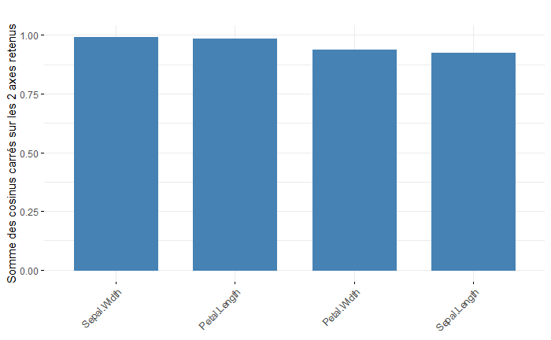

```r
# Qualité de représentation des variables sur les axes retenus de l'ACP
fviz_cos2(res.acp1_std, choice = "var", axes = 1:2) +
  labs(x="", y="Somme des cosinus carrés sur les 2 axes retenus",
       title ="")
```

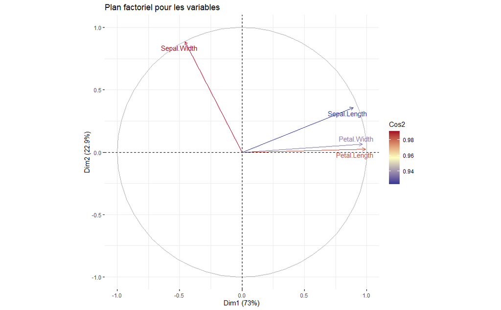

```r
# Premier plan factoriel pour les variables avec factoextra
s1 <- fviz_pca_var(res.acp1_std,
             # Variables
             col.var="cos2",
             gradient.cols = c("#313695", "#ffffbf", "#a50026"),
             repel = TRUE,
             legend.title = list(color = "Cos2"),
             show.legend = FALSE,
             title = "Plan factoriel pour les variables")
s1
```

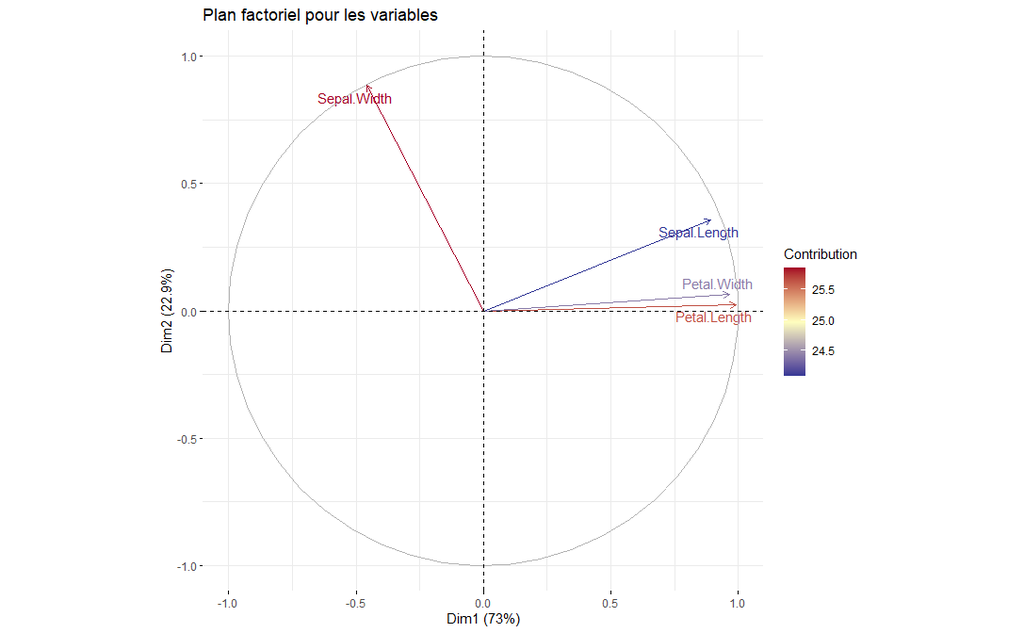

```r
s2 <- fviz_pca_var(res.acp1_std,
             # Variables
             col.var="contrib",
             gradient.cols = c("#313695", "#ffffbf", "#a50026"),
             repel = TRUE,
             legend.title = list(color = "Contribution"),
             show.legend = FALSE,
             title = "Plan factoriel pour les variables")
s2
```

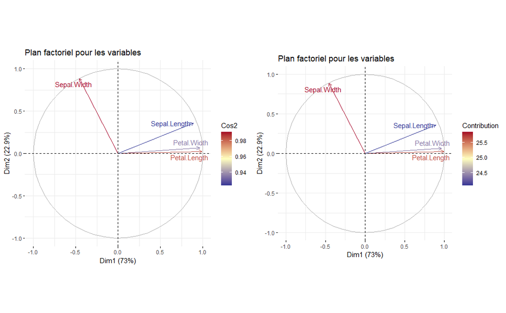

```r
ggarrange(s1, s2)
```

```r
round(res.acp1_std$var$cos2, 2)
```

```
             Dim.1 Dim.2 Dim.3 Dim.4
Sepal.Length  0.80  0.13  0.08  0.00
Sepal.Width   0.21  0.78  0.01  0.00
Petal.Length  0.98  0.00  0.00  0.01
Petal.Width   0.93  0.00  0.06  0.01
```

### Qualité de la représentation

Les cosinus carrés des variables (Cos2) permettent de mesurer les qualités de représentation des variables sur un axe, i.e. la qualité de sa projection. CO2 indique la proportion de la variance de l’élément (individu ou variable) expliquée par cet axe. C’est une métrique d’importance puisque, seules les variables bien projetées peuvent être correctement interprétées. Ces cos2 permettent de repérer le ou les axes qui concourent le plus à donner un sens à la variable. Ils sont en fait les coordonnées des variables mises au carré. La somme des cosinus carrés d’une variable sur tous les axes de l’ACP est égale à 1. La qualité de représentation d’une variable dans notre plan factoriel (ici les deux premiers axes représentant les deux premières dimensions) est simplement la somme des cosinus carrés d’une variable sur les axes retenus. Par exemple, pour la variable Sepal.Length, la qualité de représentation de la variable sur le premier axe est égale : 0.80. Pour cette même variable, la qualité de la représentation sur les deux premiers axes retenus est égale à : 0.80 + 0.13 = 0.93 (93%).

### Principale différence entre les métriques du cos2 et de la contribution

Si le cos2 illustrent la qualité de la représentation, i.e. l’importance des axes à expliquer la variables, à “l’inverse”, les contributions des variables permettent de repérer celles qui participent le plus à la formation d’un axe. La contribution mesure donc l’importance ou l’influence d’un individu ou d’une variable sur la formation d’un axe donné. Une contribution élevée signifie que l’élément a un fort impact sur la position et l’orientation de l’axe, tandis qu’une contribution faible signifie que son impact est limité. Elles s’obtiennent en divisant les cosinus carrés par la valeur propre de l’axe multiplié par 100. La somme des contributions des variables pour un axe donné est égale à 100

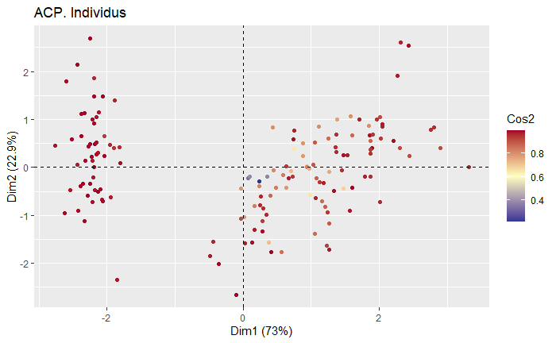

```r
fviz_pca_ind(res.acp1_std, label="none",
             # individus
             col.ind = "cos2",
             gradient.cols = c("#313695", "#ffffbf", "#a50026"),  # Utilisation de la palette ionfern
             repel = TRUE,
             title = "ACP. Individus",
             legend.title = list(color = "Cos2")

) +
  theme_grey()
```

```r
# création de la table de saturation
contributions_ind <- round(res.acp1_std$ind$contrib[, 1:2], 2)
contributions_ind
```

```
    Dim.1 Dim.2
1    1.17  0.17
2    0.99  0.33
3    1.27  0.09
4    1.20  0.26
5    1.30  0.31
6    0.98  1.62
7    1.36  0.00
8    1.13  0.04
9    1.24  0.91
10   1.09  0.16
11   1.07  0.80
12   1.23  0.01
13   1.12  0.39
14   1.58  0.67
```

[output cut: 135 more lines]

### Que représente la contribution pour les individus

La contribution d’un individu aux axes (ici les deux premiers axes) représente l’importance relative de cet individu dans la définition de la direction et de la variance de ces axes. Plus précisément, elle indique dans quelle mesure la position de cet individu sur un axe donné influence la variance capturée par cet axe. Si un individu a une contribution élevée à un axe, cela signifie qu’il est loin de l’origine dans la direction de cet axe, indiquant que ses caractéristiques jouent un rôle majeur dans la création de l’axe. Si un individu a une faible contribution, cela suggère qu’il est proche du centre de gravité des données sur cet axe et a donc moins d’influence sur la forme de l’axe. Cette information est utile pour identifier des outliers ou des individus particulièrement caractéristiques dans l’ensemble des données

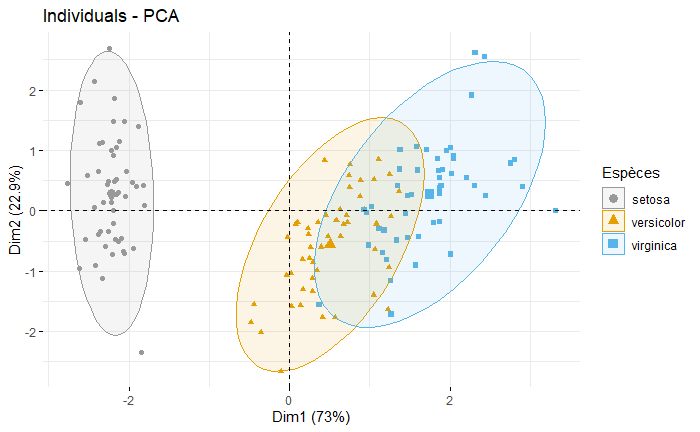

```r
fviz_pca_ind(res.acp1_std,
                col.ind = iris_clean$Species, palette = c("#999999", "#E69F00", "#56B4E9"),
                addEllipses = TRUE, label = "var",
                repel = TRUE,
                legend.title = "Espèces")
```

### Distinction entre ellipses et classification par kmeans

Les ellipses autour des groupes d’individus servent à représenter la dispersion ou la variabilité des individus au sein de chaque groupe. Ces ellipses sont souvent basées sur un certain niveau de confiance (par exemple, 95%) et représentent la région où se trouvent la plupart des individus du groupe. Elles donnent une indication visuelle de la dispersion des individus appartenant à chaque groupe. Les axes de l’ellipse montrent la direction principale de la variation au sein du groupe, et la taille de l’ellipse est proportionnelle à la variance du groupe. Ces ellipses ne sont pas des frontières strictes mais donnent une indication de la densité et de la dispersion des données.Le k-means est un algorithme de clustering qui partitionne les données en k clusters, où chaque observation appartient au cluster avec la moyenne la plus proche. Il ne prend pas en compte les directions de la variance ou la structure de corrélation entre les variables, contrairement à l’ACP qui est une méthode de réduction de dimensionnalité et non une méthode de clustering. Les clusters formés par k-means sont basés sur la proximité aux centres de clusters (les centroids), tandis que les ellipses dans l’ACP ne définissent pas de frontières fermées. Plus techniquement, les ellipses de l’ACP représentent la distribution des données en termes de variance et de covariance, ce qui n’est pas le cas pour le k-means, qui s’intéresse uniquement à la distance entre les points et les centroids.

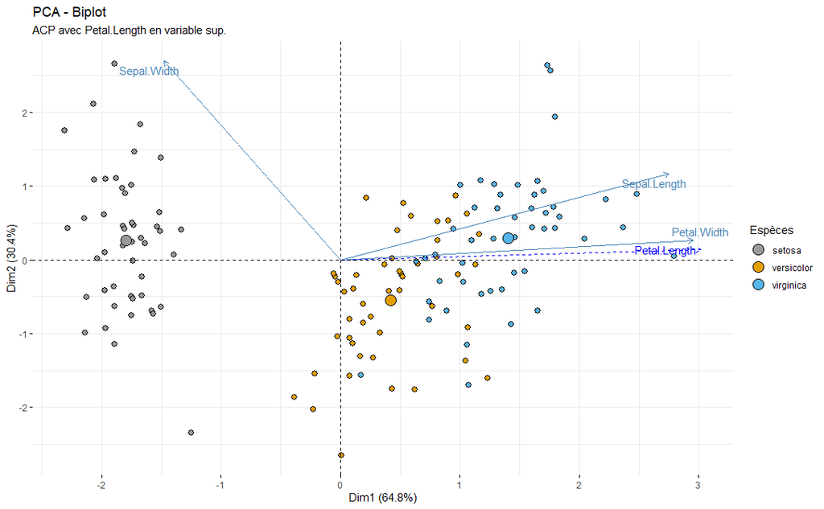

```r
# ACP avec une variable supplémentaire
res.acp2_std <- PCA(iris_clean[, -5], quanti.sup = "Petal.Length", scale.unit=TRUE, graph=FALSE)


biplot2 <- fviz_pca_biplot(res.acp2_std,
                # colorer (fill) les individu par groupe
                geom.ind = "point",
                pointshape = 21,
                pointsize = 2.5,
                fill.ind = iris_clean$Species,
                label = "var",
                legend.title = list(fill = "Espèces", color = "Variables (type)"),
                repel = TRUE,
                subtitle = "ACP avec Petal.Length en variable sup." # Éviter le surdimensionnement des étiquettes
             ) +
  fill_palette(c("#999999", "#E69F00", "#56B4E9")) +      # remplissage des individus
  color_palette("npg")

biplot2
```

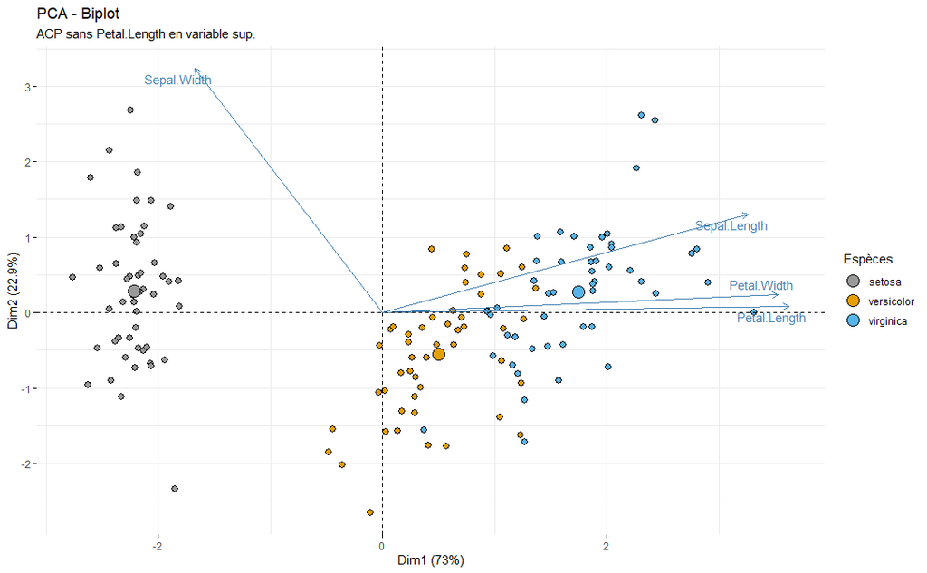

```r
biplot1b <- fviz_pca_biplot(res.acp1_std,
                # colorer (fill) les individu par groupe
                geom.ind = "point",
                pointshape = 21,
                pointsize = 2.5,
                fill.ind = iris_clean$Species,
                label = "var",
                legend.title = list(fill = "Espèces", color = "Variables (type)"),
                repel = TRUE,
                subtitle = "ACP sans Petal.Length en variable sup." # Éviter le surdimensionnement des étiquettes
             ) +
  fill_palette(c("#999999", "#E69F00", "#56B4E9")) +      # remplissage des individus
  color_palette("npg")
biplot1b
```

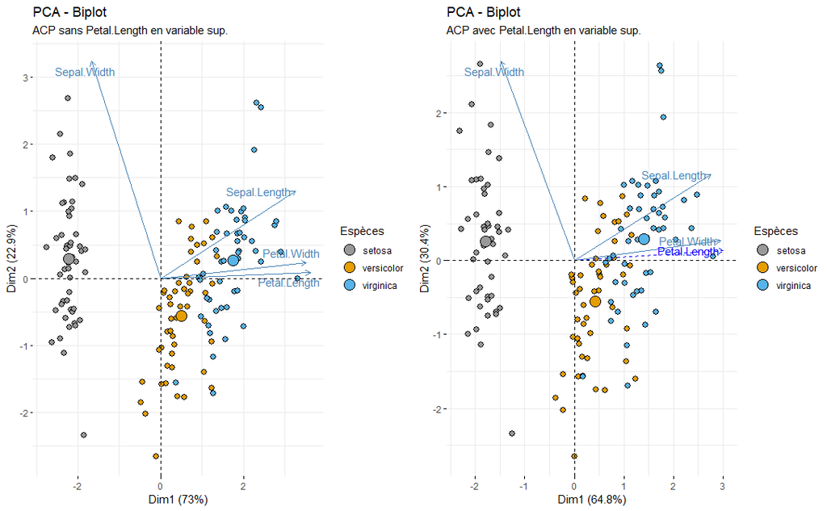

```r
ggarrange(biplot1b, biplot2)
```

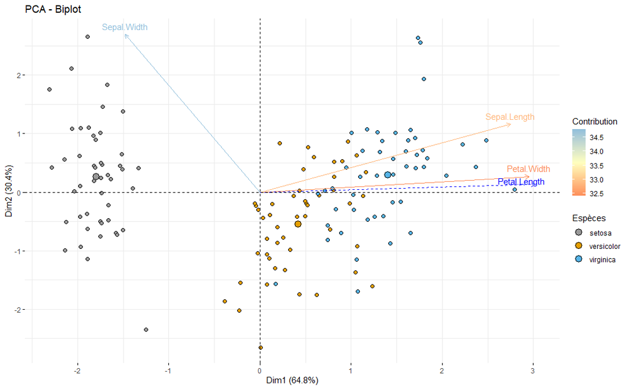

```r
fviz_pca_biplot(res.acp2_std,
                # Individuals
                geom.ind = "point",
                fill.ind = iris_clean$Species,
                pointshape = 21, pointsize = 2,
                palette = c("#999999", "#E69F00", "#56B4E9"),
                # Variables
                col.var = "contrib",
                gradient.cols = "RdYlBu",

                legend.title = list(fill = "Espèces", color = "Contribution",
                                    alpha = "Contribution")
                )
```

```r
NA
NA
NA
```

Considérer la longueur des pétales (Petal.Length) comme une variable supplémentaire modifie les liens à expliquer entre les variables et impacte la distribution de la variance expliquée entre les deux axes (dim1 passe de 73% à 64.8%, et dim2 de 22,9% à 30.4%). Cela disperse (étale) les variables sur l’axe 1 (plus grande amplitude de valeurs), et les “resserre” davantage sur l’axe 2.

*Fonctionnement de l’agorythme K-means* Le fonctionnement de l’algorithme K-means peut être décrit en plusieurs étapes, mais il repose sur le principe d’une alternance entre deux phases principales : l’expectation et la maximisation.

Étape 1: Initialisation Avant de commencer l’algorithme, on choisit K, le nombre de clusters. Ensuite, on initialise les positions des K centroïdes (les centres des clusters). Cette initialisation peut être faite de manière aléatoire ou en suivant une méthode plus sophistiquée.

Étape 2: Expectation (ou Assignation) Dans cette phase, l’algorithme affecte chaque point de données au cluster dont le centroïde est le plus proche. Cela se fait généralement en calculant la distance entre chaque point de données et chaque centroïde.

Étape 3: Maximisation (ou Mise à jour des Centroïdes) Après l’assignation des points à chaque cluster, l’étape de maximisation ajuste la position des centroïdes. Pour chaque cluster, le nouveau centroïde est alors calculé en prenant la moyenne de tous les points qui ont été attribués à ce cluster. Cela déplace le centroïde, vers la position centrale de tous les points du cluster.

Trajectoire des Centroïdes : Les étapes d’expectation et de maximisation sont répétées de manière itérative. À chaque itération, les centroïdes se déplacent, les points sont réaffectés, et ainsi de suite. Au fil de ces itérations, les centroïdes se déplacent suivant un chemin qui les amène progressivement vers la position optimale. Au début, les mouvements peuvent être importants. Au fur et à mesure des itérations, les mouvements des centroïdes deviennent plus petits, car ils se rapprochent de la position qui minimise la distance totale.

```r
# k-means clustering
km.res2 <- kmeans(iris_clean[, -c(5)], centers=3) # retrait de la variable qualitatite/catégorielle

# Visualisation dans le plan de l'ACP
fviz_pca_ind(res.pca3,
                geom.ind = "point",
                col.ind = as.factor(km.res2$cluster),
                palette = c("#999999", "#E69F00", "#56B4E9"),
                legend.title = "Cluster")
```

[output not shown]

[output not shown]

```r
# Analyse de la composition des clusters
## Moyennes des variables quantitatives
cluster_means <- aggregate(.~ km.res2$cluster, data=iris[, -c(5)], FUN=mean)
print(cluster_means)

## Proportions des différentes espèces représentées dans chaque cluster
species_table <- table(iris$Species, km.res2$cluster)
species_proportions <- prop.table(species_table, 2)
print(species_proportions)
```

[output not shown]

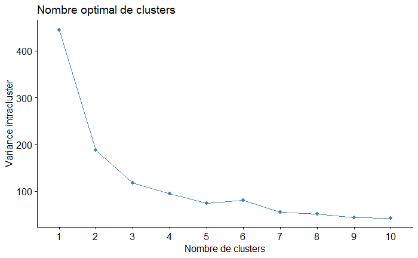

```r
# Détermination du nombre optimal de clusters
#Méthode Elbow ou "du coude"
fviz_nbclust(iris_scaled[, -c(5)], kmeans, method = "wss") +
labs(x = "Nombre de clusters", y ="Variance intracluster", title = "Nombre optimal de clusters")
```

Analyse les ruptures dans l’évolution de la variance intra-cluster

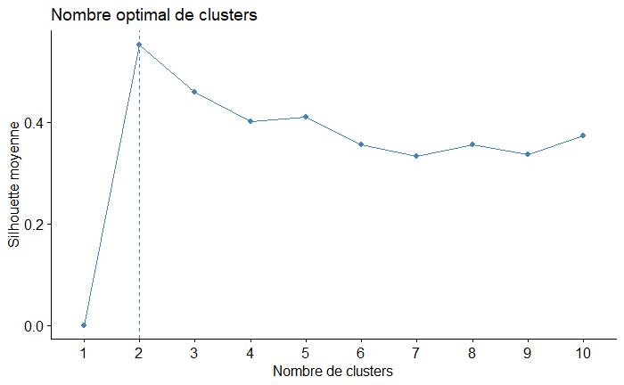

```r
# Méthode de la silhouette
fviz_nbclust(iris_scaled[, -c(5,6)], kmeans, method = "silhouette") +
labs(title = "Nombre optimal de clusters",x = "Nombre de clusters", y ="Silhouette moyenne")
```

```
*** : The Hubert index is a graphical method of determining the number of clusters.
                In the plot of Hubert index, we seek a significant knee that corresponds to a
                significant increase of the value of the measure i.e the significant peak in Hubert
                index second differences plot.
```

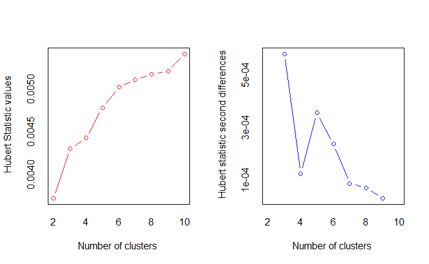

```
*** : The D index is a graphical method of determining the number of clusters.
                In the plot of D index, we seek a significant knee (the significant peak in Dindex
                second differences plot) that corresponds to a significant increase of the value of
                the measure.

* Among all indices:
* 1 proposed 2 as the best number of clusters
* 13 proposed 3 as the best number of clusters
* 1 proposed 4 as the best number of clusters
* 1 proposed 5 as the best number of clusters
* 2 proposed 6 as the best number of clusters
* 1 proposed 9 as the best number of clusters
* 4 proposed 10 as the best number of clusters

                   ***** Conclusion *****

* According to the majority rule, the best number of clusters is  3
```

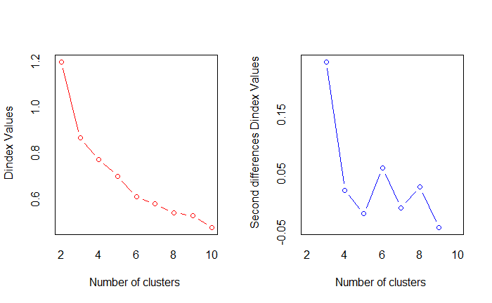

```r
# Application de NbClust
res.nbclust <- NbClust(iris_scaled, distance = "euclidean",
                  min.nc = 2, max.nc = 10,
                  method = "complete", index =  "all")
```

```
Clustering k = 1,2,..., K.max (= 10): .. done
Bootstrapping, b = 1,2,..., B (= 100)  [one "." per sample]:
.................................................. 50
.................................................. 100
```

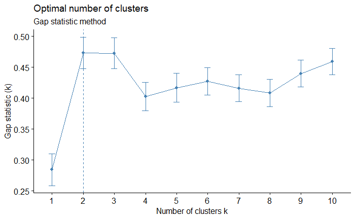

```r
fviz_nbclust(iris_scaled[, -c(5)], kmeans, nstart = 3, method = "gap_stat", nboot = 100)+
  labs(subtitle = "Gap statistic method")
```

# Projet 2 : Décathlon

```r
decat <- read.table("decathlon.csv", header=TRUE, sep=";",dec=".", row.names=1, fileEncoding="latin1", check.names=FALSE)
summary(decat)
str(decat)
sum(is.na(decat))
```

[output not shown]

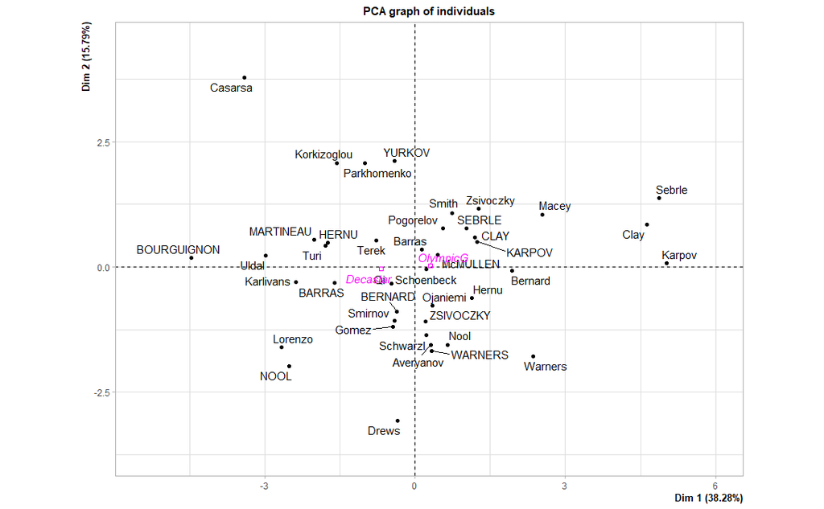

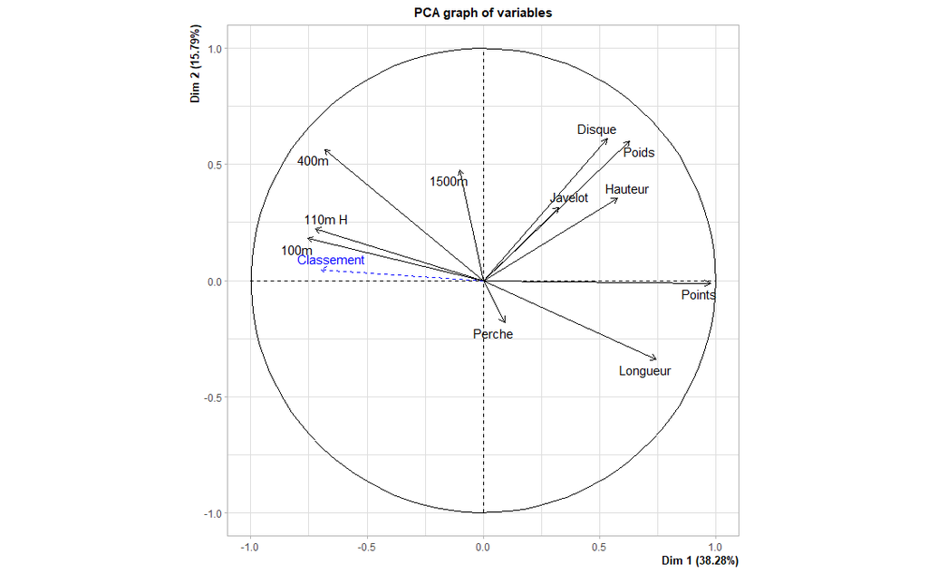

```r
res.pca.d <- PCA(decat, quali.sup= "Competition",quanti.sup="Classement", scale =TRUE, graph=TRUE)
```

```r
summary.PCA(res.pca.d)
```

```
Call:
PCA(X = decat, scale.unit = TRUE, quanti.sup = "Classement",
     quali.sup = "Competition", graph = TRUE)


Eigenvalues
                       Dim.1   Dim.2   Dim.3   Dim.4   Dim.5   Dim.6   Dim.7   Dim.8   Dim.9  Dim.10  Dim.11
Variance               4.211   1.737   1.408   1.097   0.694   0.601   0.452   0.399   0.215   0.186   0.000
% of var.             38.280  15.794  12.803   9.973   6.306   5.464   4.106   3.629   1.953   1.692   0.000
Cumulative % of var.  38.280  54.074  66.876  76.849  83.155  88.619  92.726  96.354  98.307 100.000 100.000

Individuals (the 10 first)
               Dist    Dim.1    ctr   cos2    Dim.2    ctr   cos2    Dim.3    ctr   cos2
Sebrle     |  5.508 |  4.874 13.760  0.783 |  1.375  2.655  0.062 | -0.306  0.162  0.003 |
Clay       |  5.235 |  4.627 12.399  0.781 |  0.851  1.016  0.026 |  0.242  0.102  0.002 |
Karpov     |  5.439 |  5.025 14.628  0.854 |  0.070  0.007  0.000 |  0.089  0.014  0.000 |
Macey      |  3.640 |  2.540  3.738  0.487 |  1.051  1.550  0.083 | -1.809  5.666  0.247 |
Warners    |  3.142 |  2.362  3.231  0.565 | -1.788  4.488  0.324 |  0.908  1.427  0.083 |
Zsivoczky  |  2.698 |  1.261  0.922  0.219 |  1.164  1.904  0.186 | -1.504  3.917  0.311 |
Hernu      |  1.949 |  1.130  0.739  0.336 | -0.618  0.536  0.101 | -0.890  1.372  0.209 |
Nool       |  3.172 |  0.654  0.248  0.043 | -1.552  3.384  0.240 |  1.273  2.809  0.161 |
Bernard    |  2.901 |  1.937  2.173  0.446 | -0.070  0.007  0.001 | -0.663  0.761  0.052 |
Schwarzl   |  1.991 |  0.226  0.029  0.013 | -1.355  2.578  0.463 |  0.800  1.110  0.162 |

Variables (the 10 first)
              Dim.1    ctr   cos2    Dim.2    ctr   cos2    Dim.3    ctr   cos2
100m       | -0.756 13.570  0.571 |  0.181  1.884  0.033 | -0.207  3.056  0.043 |
Longueur   |  0.744 13.147  0.554 | -0.340  6.663  0.116 |  0.199  2.810  0.040 |
Poids      |  0.630  9.430  0.397 |  0.602 20.846  0.362 | -0.015  0.017  0.000 |
Hauteur    |  0.577  7.918  0.333 |  0.354  7.200  0.125 | -0.244  4.231  0.060 |
400m       | -0.684 11.101  0.467 |  0.565 18.373  0.319 |  0.112  0.890  0.013 |
110m H     | -0.722 12.366  0.521 |  0.222  2.843  0.049 | -0.123  1.070  0.015 |
Disque     |  0.534  6.770  0.285 |  0.611 21.488  0.373 |  0.063  0.284  0.004 |
Perche     |  0.092  0.203  0.009 | -0.181  1.890  0.033 |  0.670 31.884  0.449 |
Javelot    |  0.326  2.529  0.106 |  0.316  5.734  0.100 | -0.405 11.639  0.164 |
1500m      | -0.102  0.246  0.010 |  0.477 13.072  0.227 |  0.787 43.936  0.619 |

Supplementary continuous variable
              Dim.1   cos2    Dim.2   cos2    Dim.3   cos2
Classement | -0.696  0.484 |  0.048  0.002 | -0.066  0.004 |

Supplementary categories
               Dist    Dim.1   cos2 v.test    Dim.2   cos2 v.test    Dim.3   cos2 v.test
Decastar   |  0.990 | -0.669  0.456 -1.405 | -0.040  0.002 -0.132 |  0.278  0.079  1.011 |
OlympicG   |  0.460 |  0.311  0.456  1.405 |  0.019  0.002  0.132 | -0.129  0.079 -1.011 |
```

```r
### Description des dimensions
dimdesc(res.pca.d)
```

```
$Dim.1

Link between the variable and the continuous variables (R-square)
=================================================================================
           correlation      p.value
Points       0.9781153 3.329637e-28
Longueur     0.7440250 2.477361e-08
Poids        0.6301326 1.010578e-05
Hauteur      0.5774317 7.726797e-05
Disque       0.5339317 3.240586e-04
Javelot      0.3263054 3.733051e-02
400m        -0.6836939 8.348930e-07
Classement  -0.6958314 4.407086e-07
110m H      -0.7216048 1.017774e-07
100m        -0.7559081 1.103071e-08

$Dim.2

Link between the variable and the continuous variables (R-square)
=================================================================================
         correlation      p.value
Disque     0.6109994 2.206273e-05
Poids      0.6017990 3.154802e-05
400m       0.5649770 1.188985e-04
1500m      0.4765544 1.633487e-03
Hauteur    0.3536767 2.330036e-02
Javelot    0.3156252 4.441027e-02
Longueur  -0.3402188 2.951927e-02

$Dim.3

Link between the variable and the continuous variables (R-square)
=================================================================================
        correlation      p.value
1500m     0.7866061 1.084349e-09
Perche    0.6700886 1.649969e-06
Javelot  -0.4048600 8.647479e-03
```